## 4.4 For-loops

The formula for the sum of the series $1+2+...+n$ is $n(n+1)/2$. What if we weren’t sure that was the right function? How could we check? Using what we learned about functions we can create one that computes the $S_n$:

```r
compute_s_n <- function(n){
  x <- 1:n

  sum(x)
}
```

Perhaps the simplest example of a for-loop is this useless piece of code:

```r
for (i in 1:5){
  print(i)
}
```

```
[1] 1
[1] 2
[1] 3
[1] 4
[1] 5
```

Here is the for-loop we would write for our $S_n$ example:

```r
m <- 25
s_n <- vector(length = m) # create an empty vector
for(n in 1:m){
  s_n[n] <- compute_s_n(n)
}
```

In each iteration $n=1, n=2,$ etc…, we compute $S_n$ and store it in the $n$th entry of `s_n`.

Now we can create a plot to search for a pattern:

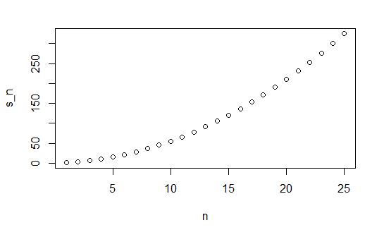

```r
n <- 1:m
plot(n, s_n)
```

If you noticed that it appears to be a quadratic, you are on the right track because the formula is $n(n+1)/2$, which we can confirm with a table:

```r
head(data.frame(s_n = s_n, formula = n*(n+1)/2))
```

|  | s_n | formula |
| --- | --- | --- |
| 1 | 1 | 1 |
| 2 | 3 | 3 |
| 3 | 6 | 6 |
| 4 | 10 | 10 |
| 5 | 15 | 15 |
| 6 | 21 | 21 |

We can also overlay the two results by using the function `lines` to draw a line over the previously plotted points:

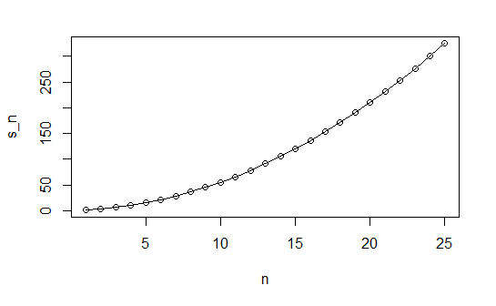

```r
plot(n, s_n)
lines(n, n*(n+1)/2)
```

## 4.5 Vectorization and functionals

Although for-loops are an important concept to understand, in R we rarely use them. As you learn more R, you will realize *vectorization* is preferred over for-loops since it results in shorter and clearer code. We already saw examples in the Vector Arithmetic Section. A *vectorized* function is a function that will apply the same operation on each of the vectors.

```r
x <- 1:10
sqrt(x)
```

```
 [1] 1.000000 1.414214 1.732051 2.000000 2.236068 2.449490 2.645751 2.828427 3.000000 3.162278
```

```r
y <- 1:10
x*y
```

```
 [1]   1   4   9  16  25  36  49  64  81 100
```

To make this calculation, there is no need for for-loops. However, not all functions work this way. For instance, the function we just wrote, `compute_s_n`, does not work element-wise since it is expecting a scalar. This piece of code does not run the function on each entry of `n`:

```r
n <- 1:25
compute_s_n(n)
```

```
numerical expression has 25 elements: only the first used
```

```
[1] 1
```

*Functionals* are functions that help us apply the same function to each entry in a vector, matrix, data frame or list. Here we cover the functional that operates on numeric, logical and character vectors: `sapply`.

The function `sapply` permits us to perform element-wise operations on any function. Here is how it works:

```r
x <- 1:10
sapply(x, sqrt)
```

```
 [1] 1.000000 1.414214 1.732051 2.000000 2.236068 2.449490 2.645751 2.828427 3.000000 3.162278
```

> However, sqrt itself seems to be applicable to element-wise operation.

```r
x <- 1:10
sqrt(x)
```

```
 [1] 1.000000 1.414214 1.732051 2.000000 2.236068 2.449490 2.645751 2.828427 3.000000 3.162278
```

> They show same result. What happened?

Other functions are `apply`, `lapply`, `tapply`, `mapply`, `vapply`, and `replicate`. We mostly use `sapply`, `apply` and `replicate` in this book, but we recomment familiarizing yourselves with the others as they can be very useful.

## 4.6 Exercises

1. What will this conditional expression return?

```r
x <- c(1,2,-3,4)

if(all(x>0)){
  print("All Positives")
} else{
  print("Not all positives")
}
```

```
[1] "Not all positives"
```

2. Which of the following expressions is always `FALSE` when at least one entry of a logical vector `x` is TRUE?

A. `all(x)`

B. `any(x)`

C. `any(!x)`

D. `all(!x)`

Answer: D

3. The function `nchar` tells you how many characters long a character vector is.

Write a line of code that assigns to the object `new_names` the state abbreviation when the state name is longer than 8 characters.

Answer: 우선 `state.name`중 `nchar`가 8 보다 큰 주의 index를 추출한다.

```r
which(nchar(state.name)>8)
```

```
 [1]  5  7 18 21 23 24 29 30 31 33 34 38 39 40 41 42 47 48 49
```

이를 이용해 `state.abb`에서 indexing해낸다.

```r
new_names <- vector(length = m)
new_names <- state.abb[which(nchar(state.name)>8)]
new_names
```

```
 [1] "CA" "CT" "LA" "MA" "MN" "MS" "NH" "NJ" "NM" "NC" "ND" "PA" "RI" "SC" "SD" "TN" "WA" "WV" "WI"
```

4. Create a function `sum_n` that for any given value, say `n`, computes the sum of the integers from 1 to n (inclusive). Use the function to determine the sum of integers from 1 to 5,000.

```r
sum_n <- function(n){
  sum(1:n)
}
```

```r
sum_n(5000)
```

```
[1] 12502500
```

여기에 plot으로 한 번 확인해보자.

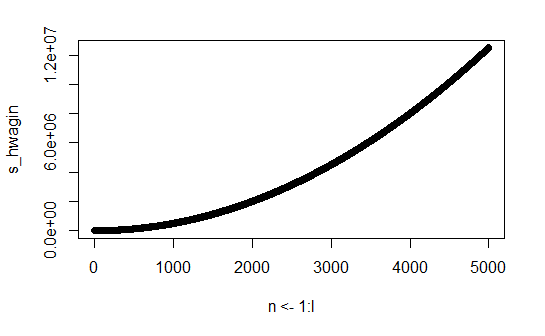

```r
l <- 5000
s_hwagin <- vector(length = l)

for (n in 1:l){
  s_hwagin[n] <- sum_n(n)
}

plot(n <- 1:l, s_hwagin)
lines(n, n*(n+1)/2)
```

5. Create a function `altman_plot` that takes two arguments, `x` and `y`, and plots the difference against the sum.

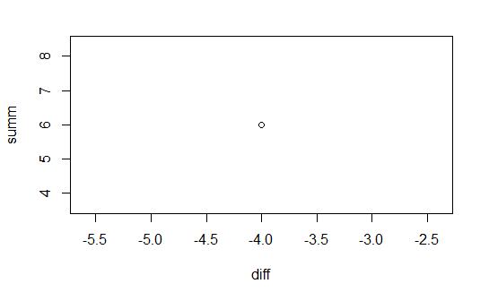

```r
altman_plot <- function(x, y){
  diff <- x-y
  summ <- x+y

  plot(diff, summ)
}

altman_plot(1,5)
```

6. After running to code below, what is the value of `x`?

```r
x <- 3
my_func <- function(y){
  x <- 5
  y+5
}
```

Answer: Value of x should remain 3 because the variables used within the functions are *local*. Let’s find it out.

```r
x
```

```
[1] 3
```

7. Write a function `compute_s_n` that for any given $n$ computes the sum $S_n = 1^2+2^2+3^2+...n^2$. Report the value of the sum when $n=10$.

```r
compute_s_n <- function(n){
  squares <- vector(length = n)
  for (i in 1:n){
    squares[i] <- i*i
  }
  sum(squares)
}

compute_s_n(10)
```

```
[1] 385
```

8. Define an empty numerical vector `s_n` of size 25 using `s+n <- vector("numeric", 25)` and store in the results of $S_1, S_2, ... S_25$ using a for-loop.

```r
m <- 25
n <- 1:m

s_n <- vector("numeric", 25)
for (a in n){
s_n[a] <- compute_s_n(a)
}
s_n
```

```
 [1]    1    5   14   30   55   91  140  204  285  385  506  650  819 1015 1240 1496 1785 2109 2470 2870 3311 3795
[23] 4324 4900 5525
```

```r
plot(n, s_n)
```

[output not shown]

9. Repeat exercise 8, but this time use `sapply`.

그냥 바로 function `compute_s_n`을 벡터인 n에 쓰려고 하면 에러가 뜬다. Function은 각각의 scalar값에 대해 값을 계산해주기 때문이다.

```r
n <- 1:25
compute_s_n(n)
```

```
Error in vector(length = n) : invalid 'length' argument
```

데이터를 다룰 때, 원자별, 그룹별로 함수를 적용할 경우가 많다. Apply 계열의 함수는 데이터 구조를 갖는 R object 를 input 으로 받아 원소 별 혹은 그룹별로 함수를 적용시키는 것이다.

input 과 output 의 형태에 따라 여러 종류로 나뉜다.

> apply (input : array, output : array)  
> lapply (input : list or vector, output : list)  
> sapply (input : list or vector, output : vector or array)  
> vapply (input : list or vector, output : vector or array)  
> tapply (input : list or vector and factor, output : vector or array)  
> mapply (input : list or vector, output : vector or array)

출처: https://3months.tistory.com/389

```r
n <- 1:25
s_n <- sapply(n, compute_s_n)
s_n
```

```
 [1]    1    5   14   30   55   91  140  204  285  385  506  650  819 1015 1240 1496 1785 2109 2470 2870 3311 3795
[23] 4324 4900 5525
```

```r
plot(n, s_n)
```

[output not shown]

10. Repeat exercise 8, but this time use `map_dbl`.

```r
library(purrr)
n <- 1:25
s_n <- map_dbl(n, compute_s_n) #그냥 function 이름만 적으면 된다!!! ㅠㅠ
s_n
```

```
 [1]    1    5   14   30   55   91  140  204  285  385  506  650  819 1015 1240 1496 1785 2109 2470 2870 3311 3795
[23] 4324 4900 5525
```

```r
plot(n, s_n)
```

[output not shown]

12. Confirm that the formula for this sum is $S_n=n(n+1)(2n+1)/6$.

```r
n <- 1:25
plot(n, s_n)
```

[output not shown]

```r
lines(n, n*(n+1)*(2n+1)/6)
```

```
Error: unexpected symbol in "lines(n, n*(n+1)*(2n"
```